# Fitbit Device Usage Analysis to Inform Bellabeat Marketing Strategy

Michealea Faustine

2025-09-01

# Executive Summary

This analysis explores Fitbit usage data to identify trends in wellness tracking behaviors, with the goal of informing Bellabeat’s marketing strategy for its Leaf wearable.

Based on these findings, I developed data-informed marketing strategies focused on highlighting Leaf’s automatic stress and reproductive health tracking, targeting wellness-focused women with habit-building and consistency, promoting user stories that reflect behavior change over time.

Tools: R, tidyverse, and ggplot2 This project was completed as part of the Google Data Analytics Certificate.

# Introduction

### BellaBeat

A woman’s wellness company that has helped millions of women track their cycle, pregnancies, and live more in sync with their cycles. https://bellabeat.com/about-us/

**Business Goals:** Empower women to take control of their health by providing them with technology-driven designs that blend design and function.

**Products:** * Bellabeat app: provides users with health data related to their activity, sleep, stress, menstrual cycle, and mindfulness habits * Leaf: connects to the Bellabeat app to track activity, sleep, and stress * Time: track the user activity, sleep, and stress * Spring: water bottle that tracks daily water intake * Bellabeat Membership: 24/7 guidance on nutrition, activity, sleep, health and beauty, and mindfulness based on their lifestyle and goals

**Advertising method:** digital marketing (Google Search, Facebook pages, Instagram, Twitter engagement)

# Problems

## Business Task

Focus on a product and analyze smart device usage data in order to gain insights into how people are already using their smart devices. Find high-level recommendations for how these trends can inform Bellabeat marketing strategy.

## Goal

The Bellabeat Leaf tracks activity, sleep, stress, meditation, and reproductive health. Since the Fitbit data focuses primarily on activity and sleep, analyzing user behavior in these areas allow us to identify trends and create marketing strategies for Leaf, especially for users already engaged with similar tracking habits.

1. What are some trends in smart device usage?
2. How could these trends apply to Bellabeat customers?
3. How could these trends help influence Bellabeat marketing strategy?

# Load Fitbit datasets

```r
knitr::opts_chunk$set(echo = TRUE)
library(tidyverse)
library(readxl)
library(sugrrants)
library(janitor)
daily_activity <- read_excel("Fitbit Data/dailyActivity_merged.xlsx")
sleep_log <- read_excel("Fitbit Data/sleepDay_merged.xlsx")
weight_log <- read_excel("Fitbit Data/weightLogInfo_merged.xlsx")
```

## Exploratory Data Overview

### Checking and Removing Duplicates

```r
daily_activity <- daily_activity %>% distinct()
sleep_log <- sleep_log %>% distinct()
weight_log <- weight_log %>% distinct()
```

### Cleaning Column Names

To improve readability and consistency, we use the clean_names(data, case=‘snake’) function to change all column names into lower case and replace spaces or uppercase with an underscore.

```r
daily_activity <- clean_names(daily_activity, case='snake')
sleep_log <- clean_names(sleep_log, case='snake')
weight_log <- clean_names(weight_log, case='snake')
colnames(daily_activity)
```

```
##  [1] "id"                         "activity_date"
##  [3] "total_steps"                "total_distance"
##  [5] "tracker_distance"           "logged_activities_distance"
##  [7] "very_active_distance"       "moderately_active_distance"
##  [9] "light_active_distance"      "sedentary_active_distance"
## [11] "very_active_minutes"        "fairly_active_minutes"
## [13] "lightly_active_minutes"     "sedentary_minutes"
## [15] "calories"
```

```r
colnames(sleep_log)
```

```
## [1] "id"                   "sleep_day"            "total_sleep_records"
## [4] "total_minutes_asleep" "total_time_in_bed"
```

```r
colnames(weight_log)
```

```
## [1] "id"               "date"             "weight_kg"        "weight_pounds"
## [5] "fat"              "bmi"              "is_manual_report" "log_id"
```

After cleaning the names, want to understand how many unique users are representerd in each dataset. Since each user can have multiple entries (across different dates), it’s important to count distinct user IDs.

```r
n_distinct(daily_activity$id)
```

```
## [1] 33
```

```r
n_distinct(sleep_log$id)
```

```
## [1] 24
```

```r
n_distinct(weight_log$id)
```

```
## [1] 8
```

There are significantly fewer users who have logged their weight compared to those who have logged activity or sleep data. When Fitbit is worn to bed, it automatically tracks the users’ sleep, but weight needs the users’ manual input.

## Transforming the Data set

The date columns in the dataset include both date and time, but for the following analysis, we only need the date in the format of ‘mm/dd/yy’. Therefore, we will convert these columns into the proper date using as.Date() function.

```r
weight_log <- weight_log %>%
  mutate(date = as.Date(date, format = "%m/%d/%Y"))

sleep_log <- sleep_log %>%
  mutate(date = as.Date(sleep_day, format = "%m/%d/%Y"))

daily_activity <- daily_activity %>%
  mutate(date = as.Date(activity_date, format = "%m/%d/%Y"))
```

## Summary of each dataframe

For each of the data frame, we use the summary() function to generate basic descriptive statistic for the key variables in the dataset. This provides a quick overview of users’ physical activity patterns. ### Daily Activity

```r
daily_activity %>% summary()
```

```
##        id            activity_date       total_steps    total_distance
##  Min.   :1.504e+09   Length:940         Min.   :    0   Min.   : 0.000
##  1st Qu.:2.320e+09   Class :character   1st Qu.: 3790   1st Qu.: 2.620
##  Median :4.445e+09   Mode  :character   Median : 7406   Median : 5.245
##  Mean   :4.855e+09                      Mean   : 7638   Mean   : 5.490
##  3rd Qu.:6.962e+09                      3rd Qu.:10727   3rd Qu.: 7.713
##  Max.   :8.878e+09                      Max.   :36019   Max.   :28.030
##  tracker_distance logged_activities_distance very_active_distance
##  Min.   : 0.000   Min.   :0.0000             Min.   : 0.000
##  1st Qu.: 2.620   1st Qu.:0.0000             1st Qu.: 0.000
##  Median : 5.245   Median :0.0000             Median : 0.210
##  Mean   : 5.475   Mean   :0.1082             Mean   : 1.503
##  3rd Qu.: 7.710   3rd Qu.:0.0000             3rd Qu.: 2.052
##  Max.   :28.030   Max.   :4.9421             Max.   :21.920
##  moderately_active_distance light_active_distance sedentary_active_distance
##  Min.   :0.0000             Min.   : 0.000        Min.   :0.000000
##  1st Qu.:0.0000             1st Qu.: 1.945        1st Qu.:0.000000
##  Median :0.2400             Median : 3.365        Median :0.000000
##  Mean   :0.5675             Mean   : 3.341        Mean   :0.001606
##  3rd Qu.:0.8000             3rd Qu.: 4.783        3rd Qu.:0.000000
##  Max.   :6.4800             Max.   :10.710        Max.   :0.110000
##  very_active_minutes fairly_active_minutes lightly_active_minutes
##  Min.   :  0.00      Min.   :  0.00        Min.   :  0.0
##  1st Qu.:  0.00      1st Qu.:  0.00        1st Qu.:127.0
##  Median :  4.00      Median :  6.00        Median :199.0
##  Mean   : 21.16      Mean   : 13.56        Mean   :192.8
##  3rd Qu.: 32.00      3rd Qu.: 19.00        3rd Qu.:264.0
##  Max.   :210.00      Max.   :143.00        Max.   :518.0
##  sedentary_minutes    calories         date
##  Min.   :   0.0    Min.   :   0   Min.   :2016-04-12
##  1st Qu.: 729.8    1st Qu.:1828   1st Qu.:2016-04-19
##  Median :1057.5    Median :2134   Median :2016-04-26
##  Mean   : 991.2    Mean   :2304   Mean   :2016-04-26
##  3rd Qu.:1229.5    3rd Qu.:2793   3rd Qu.:2016-05-04
##  Max.   :1440.0    Max.   :4900   Max.   :2016-05-12
```

The summary statistics provide an overview of user behavior in terms of physical activity and calories burned: * id: Represents unique users in the dataset * activity_date/date: Indicates when each activity was recorded. Useful for analyzing trends over time. * total_steps and total_distance: Both of these variables can be used interchangeably because they reflect the user’s overall daily movement. * calories: Ranges from 0 to 4,900 with a mean of ~2,304. This metric shows the total calories burned and can be used to assess the relationship between physical activity and energy expenditure. * active_minutes (very_active_minutes, fairly_active_minutes, lightly_active_minutes, sedentary_minutes): These variables represent the duration of time users spend at different intensity levels. The variables are important for understanding how different activity types contribute to calories burned and for segmenting users by activity patterns. * Redundant or less informative variables: * active_distance: Relatively low values across users, suggesting minimal variation or usage. This metric may therefore offer limited analytical value compared to active minutes. * tracker_distance: Nearly identical to total_distance. * Logged_activities_distance: Mostly zero entries, which suggests users rarely manually log distance.

### Sleep Activity

```r
sleep_log %>%
  select(total_minutes_asleep, total_time_in_bed) %>%
  summary()
```

```
##  total_minutes_asleep total_time_in_bed
##  Min.   : 58.0        Min.   : 61.0
##  1st Qu.:361.0        1st Qu.:403.8
##  Median :432.5        Median :463.0
##  Mean   :419.2        Mean   :458.5
##  3rd Qu.:490.0        3rd Qu.:526.0
##  Max.   :796.0        Max.   :961.0
```

The sleep_log dataset provides insights into users’ sleep behavior. For this analysis, the focus is on the two key variables: * total_minutes_asleep: The average is about 419.5 minutes which is 6.99 hours of sleep, which aligns closely with the recommended amount of sleep for adults. We also see that the minimum sleep recorded is 58 minutes, suggesting that nap times may be included. * total_time_in_bed: This variable reflects the overall time users spent in bed and is closely related to total_minutes_asleep. By comparing these two values, we can estimate sleep efficiency, which is useful for identifying sleep quality (time asleep vs time in bed).

### Weight Log

```r
weight_log %>%
  select(weight_kg, bmi) %>%
  summary()
```

```
##    weight_kg           bmi
##  Min.   : 52.60   Min.   :21.45
##  1st Qu.: 61.40   1st Qu.:23.96
##  Median : 62.50   Median :24.39
##  Mean   : 72.04   Mean   :25.19
##  3rd Qu.: 85.05   3rd Qu.:25.56
##  Max.   :133.50   Max.   :47.54
```

Although only 8 distinct users log weight-related data, analyzing weight_kg and bmi can provide useful indicators of progress or behavioral change among the small group of engaged users. * weight_kg: Records users’ body weight at different points in time. * bmi: Provides context for weight by accounting for user height.

**Note: There are limited samples for this analysis.**

# Merging Datasets

In order to get all users who log all three types of data, only activity and sleep, only activity, only weight, etc…, a full_join() function should be used to preserve all rows. This merge will create missing values which identifies what user didn’t log.

```r
# Get the list of all users with all three logs
merge_all <- daily_activity %>%
  full_join(sleep_log, by=c("id", "date")) %>%
  full_join(weight_log, by=c("id", "date"))
```

From the merge_all dataframe, we can create another dataframe that tells us how many days each user logged sleep, weight, and activity.

```r
tracking_stats <- merge_all %>%
  group_by(id) %>%
  summarise(
    days_with_sleep=sum(!is.na(total_minutes_asleep)),
    days_with_activity=sum(!is.na(total_steps)),
    days_with_weight=sum(!is.na(weight_kg))
  ) %>%
  select(
    id, days_with_sleep, days_with_activity, days_with_weight
  )

min(tracking_stats$days_with_activity)
```

```
## [1] 4
```

The minimum number of days that a user log their physical activity is 4 days. This shows that all users log their physical activity whether it’s manually or automatically. Next, we will figure out exactly how many users log the activity types. The following dataframe shows the category of users by logging pattern.

```
## # A tibble: 4 × 2
##   segment               n
##   <chr>             <int>
## 1 Activity + Sleep     18
## 2 Activity + Weight     2
## 3 Activity Only         7
## 4 All Three             6
```

# Analysis

### Average Steps vs Calories Burned

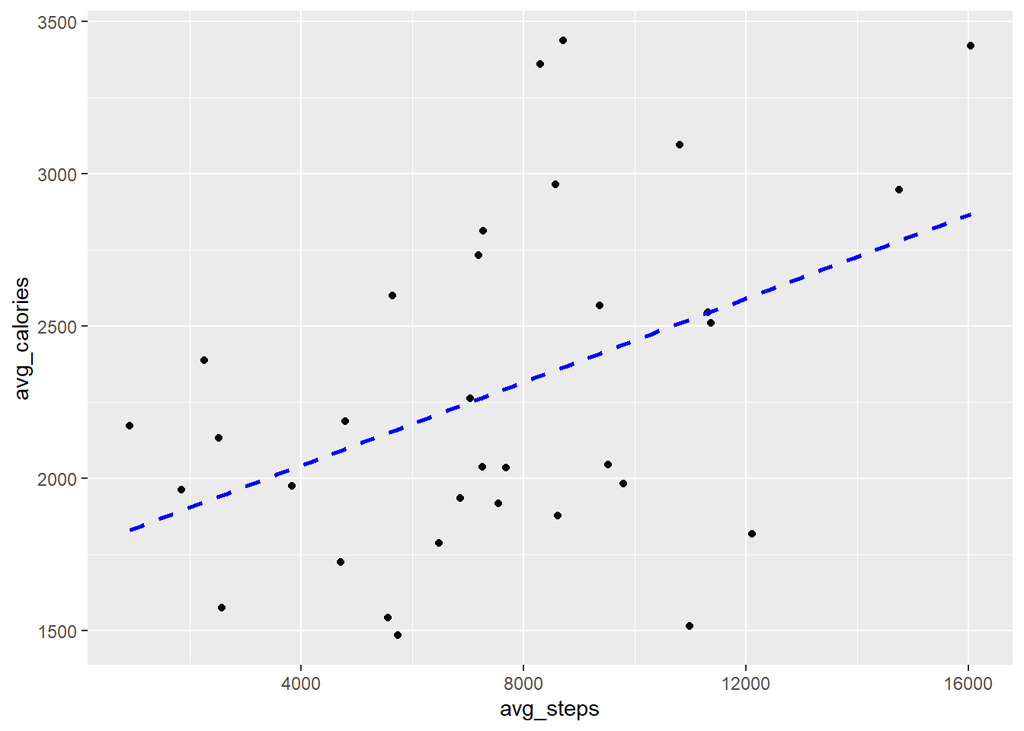

```r
# subset for average steps per day and calories by user
avg_steps_calories <- daily_activity %>%
  group_by(id) %>%
  summarise(
    avg_steps = mean(total_steps, na.rm = TRUE),
    avg_calories = mean(calories, na.rm = TRUE)
  )

# plot for calories
ggplot(avg_steps_calories, aes(x= avg_steps, y=avg_calories)) +
  geom_point() + geom_smooth(method = "lm", se = FALSE, color = "blue", linetype = "dashed")
```

The plot shows a positive correlation with the average calories and average steps of each user. As expected, there is a positive correlation between steps and calories burned. However, the wide spread of points around the line suggests that other activities (i.e. high-intensity workouts) may burn more calories than step count alone would indicate. This highlights the value of smart wearables like the Bellabeat Leaf, which go beyond simple step tracking. By providing users with a fuller picture of their physical activity, these devices can help optimize health outcomes and encourage more personalized wellness journeys.

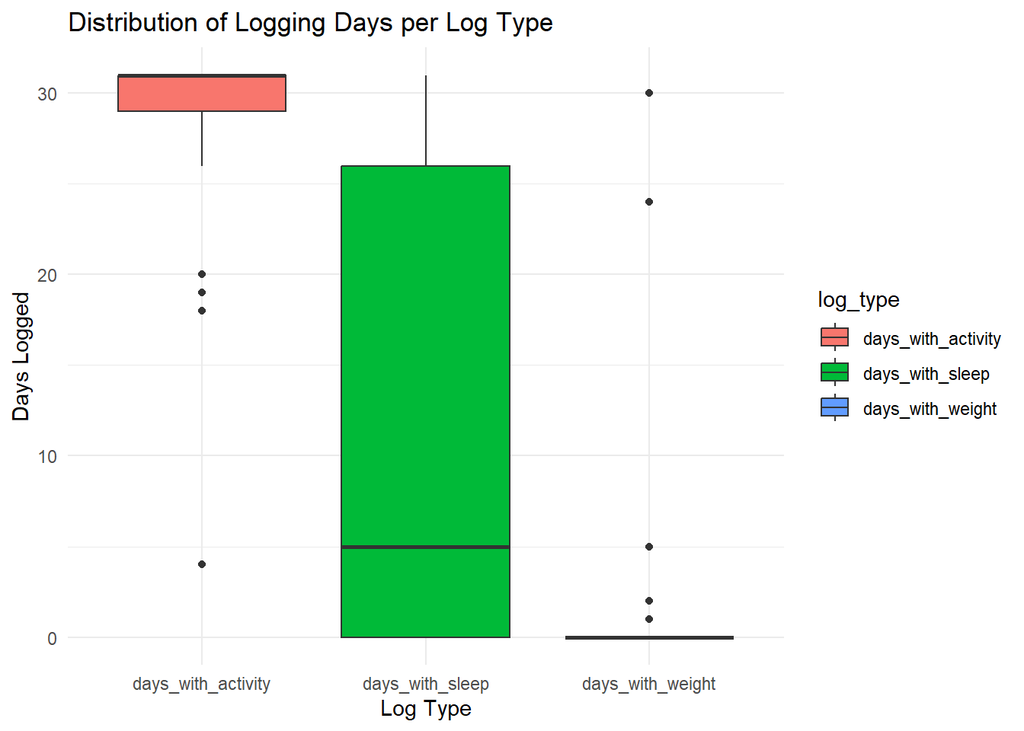

Users log their activity the most, their sleep less frequently, and their weight the least. There is high variability in how frequently users log their sleep.

### A closer look at a consistent user

After a quick look at the tracking_stats subset, we find that there is a user who log their weight, sleep, and activity for about 30 days, which is the maximum days that a user log their weight.

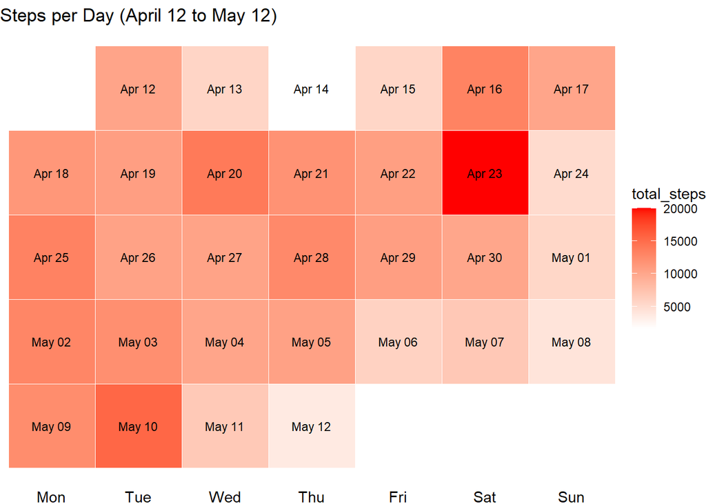

### Calories Heatmap Calendar

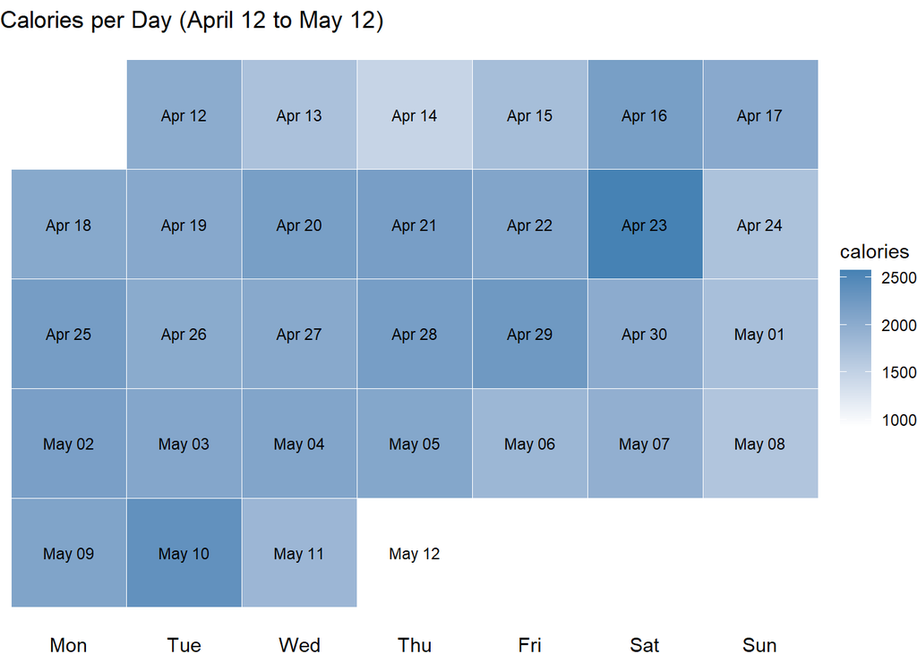

### TotalSleep

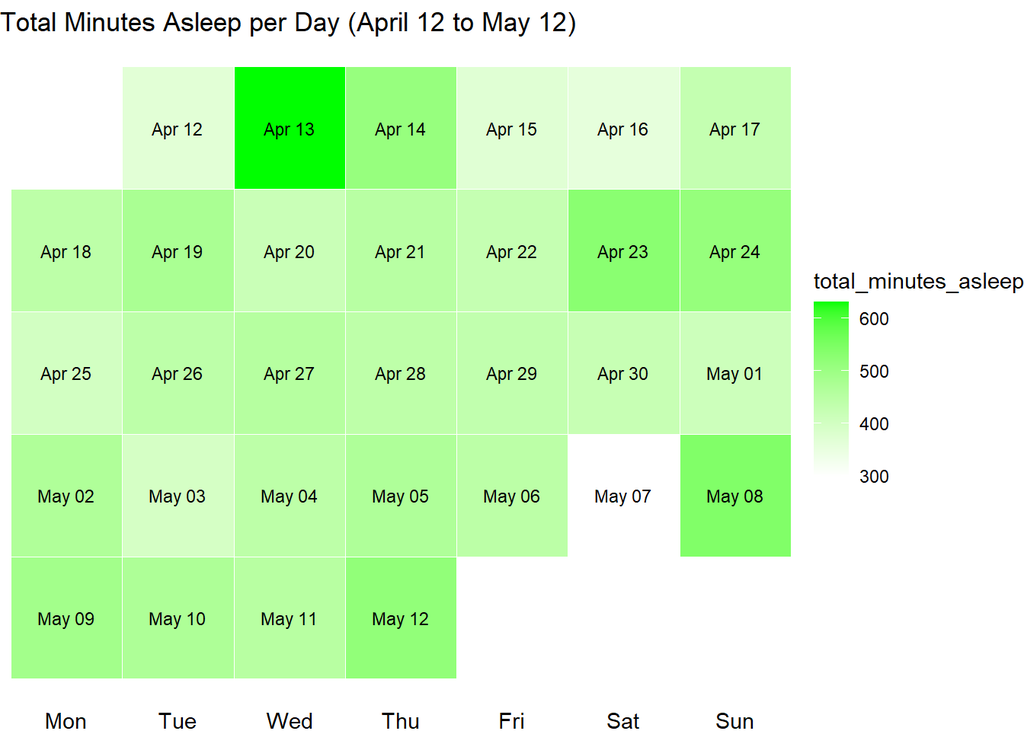

These calendar heatmaps visually show how user behavior changse over time - across steps, calories, abd sleep. The color intensity makes it easier to spot patterns in consistency and effort over the 30 days.

### Creating an engagement score

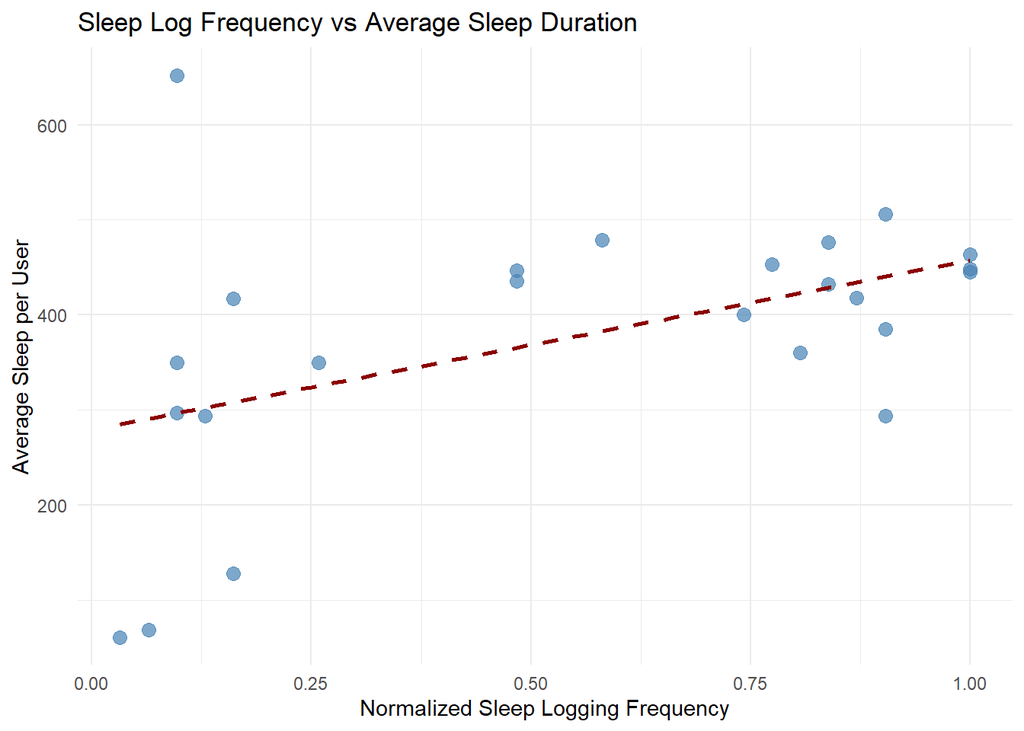

This positive correlation suggests that users who regularly log their sleep tend to sleep more consistently or longer. This supports the idea that self-tracking encourages mindful behavior, a key value proposition for Bellabeat Leaf, which promotes self-awareness around wellness.

### Segmenation by Users’ Logging Patterns

Not all users engage with fitbit the same way. To better understand the types of users, we can segment them into groups based on the types of data they track: all three(activity, sleep, and weight), activity and sleep only, or activity only.

[output not shown]

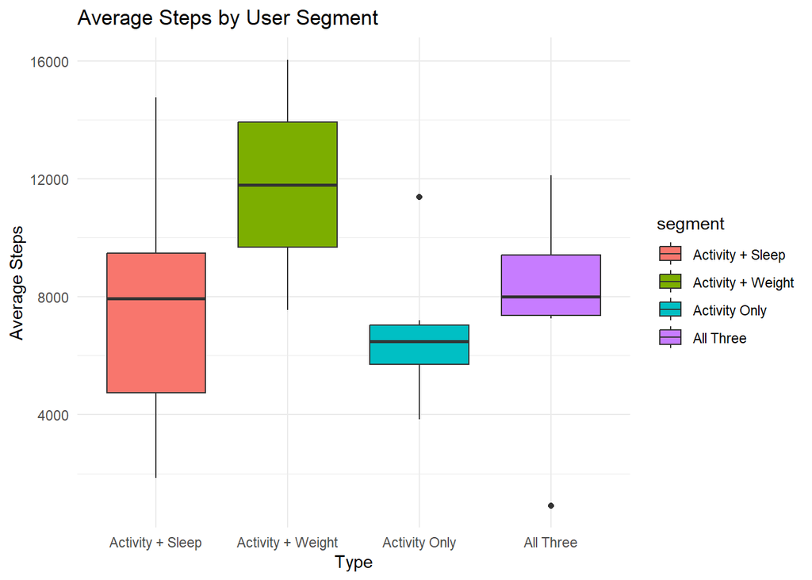

Users who track only physical activity have the lowest average step counts, which may indicate more casual engagement with their wearable. These users are likely passive users who aren’t leveraging the full functionality of the device.

In contrast, users logging activity and weight demonstrate the highest step averages (~12,000 per day), suggesting a more goal-oriented or health-conscious behavior, possibly motivated by weight management. However, this group also has a small sample size (n = 2), so additional user data would be necessary to validate this trend.

Users who track activity and sleep show moderate step counts, with a wide interquartile range. This variability suggests a mix of user types, but overall, this group may represent users interested in general wellness rather than high-performance fitness goals.

# Conclusion

These findings indicate that Bellabeat’s Leaf is most effective when it is simplified and automates data tracking, making it easier for users to maintain consistent engagement. By uncovering these trends, Bellabeat’s marketing strategy should emphasize convenience, particularly highlighting automated tracking. Furthermore, with Bellabeat’s Leaf tracks activity, sleep, stress, meditation and reproductive health automatically by syncing with the app.

Through supporting and encouraging consistent, comprehensive health tracking, Bellabeat helps women make informed decisions about their well being. The following high-level recommendations outlines how Bellabeat can use marketing strategies to boost users’ engagement and introduce new users to Bellabeat.

# Recommendations

1. Platform: Google Search Objective: Capture users actively searching for health devices for tracking their physical health User Behavior: Users comparing features between brands Target: Health-conscious women comparing wearables Tactics: create comparison-focused content highlighting unique features like reproductive health tracking and stress management
2. Platform: Facebook and Instagram Objective: Drive awareness on the product and find emotional connection through storytelling User Behavior: Browsing casually Target: busy professionals, health-conscious users without optimizing performance Tactics: Share successful stories from Bellabeat users’ on how they become more mindful of their health, and how they optimize their calorie burn through Bellabeat’s product features
3. Platform: Twitter Purpose: Engage in conversations User Behavior: Looking for health topics Target: well-informed users following health brands Recommendation: Encourage users in logging their menstrual cycle and Bellabeat can predict future cycles, highlighting automatic tracking